# DS_HW_1_MANDELI

Question 1

```r
library(mosaic)
head(RailTrail)
```

```
##   hightemp lowtemp avgtemp spring summer fall cloudcover precip volume
## 1       83      50    66.5      0      1    0        7.6   0.00    501
## 2       73      49    61.0      0      1    0        6.3   0.29    419
## 3       74      52    63.0      1      0    0        7.5   0.32    397
## 4       95      61    78.0      0      1    0        2.6   0.00    385
## 5       44      52    48.0      1      0    0       10.0   0.14    200
## 6       69      54    61.5      1      0    0        6.6   0.02    375
##   weekday dayType
## 1    TRUE weekday
## 2    TRUE weekday
## 3    TRUE weekday
## 4   FALSE weekend
## 5    TRUE weekday
## 6    TRUE weekday
```

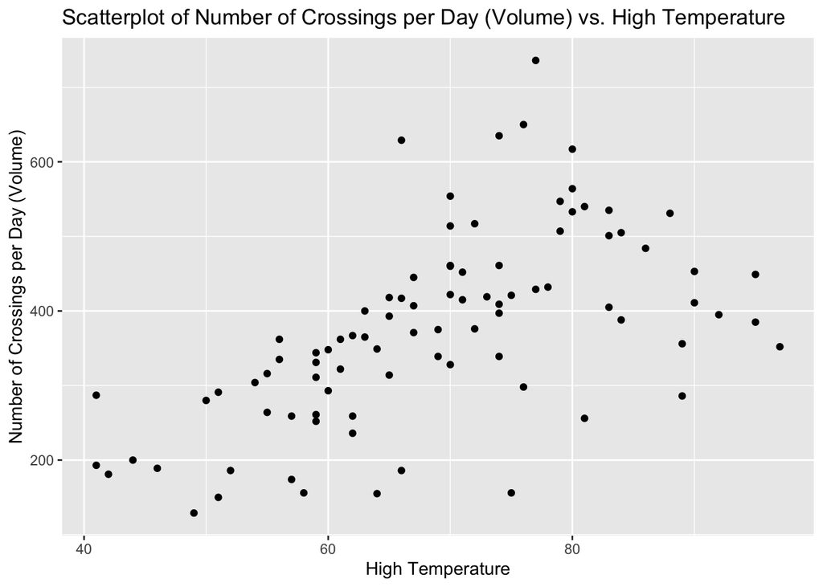

```r
ggplot(data=RailTrail)+
  geom_point(aes(y=volume, x= hightemp))+
  xlab('High Temperature')+
  ylab('Number of Crossings per Day (Volume)')+
  ggtitle('Scatterplot of Number of Crossings per Day (Volume) vs. High Temperature')
```

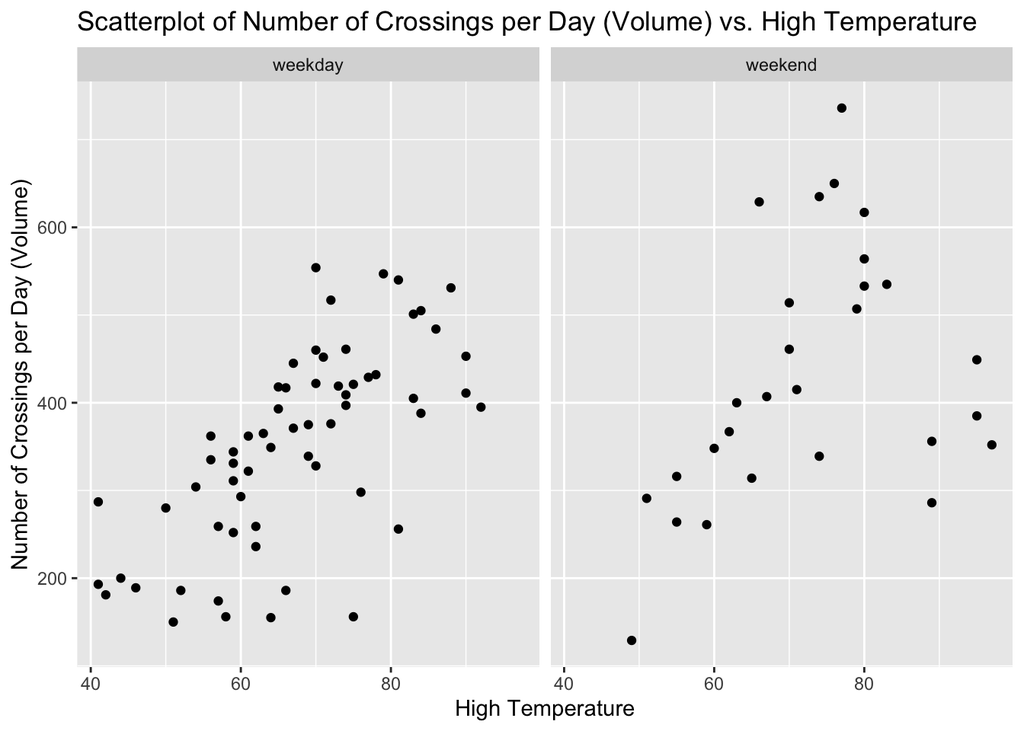

```r
ggplot(data=RailTrail,aes(y=volume, x= hightemp))+
  geom_point()+
  xlab('High Temperature')+
  ylab('Number of Crossings per Day (Volume)')+
  ggtitle('Scatterplot of Number of Crossings per Day (Volume) vs. High Temperature')+
  facet_wrap(~dayType)
```

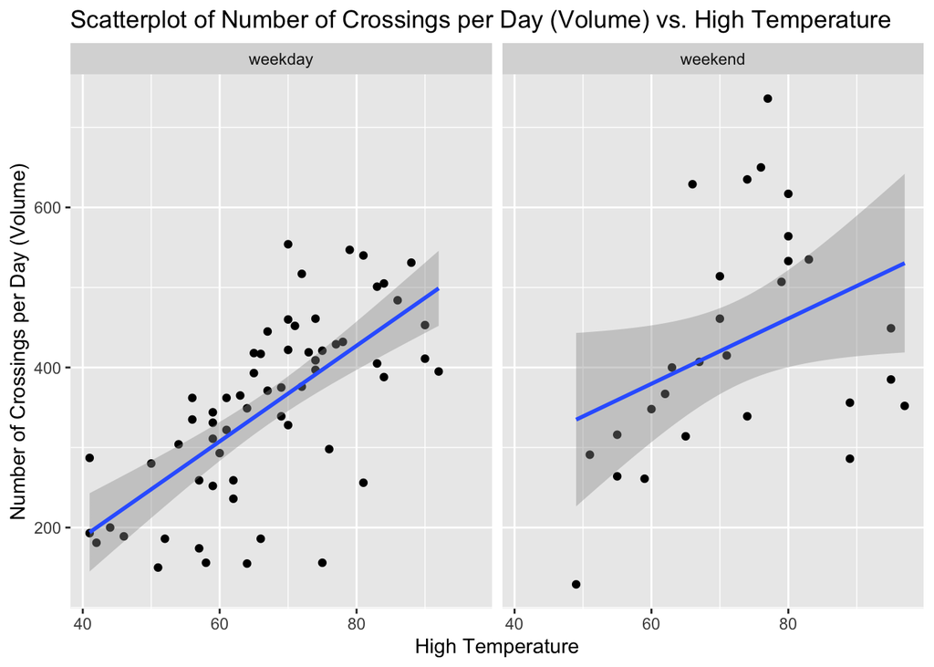

```r
ggplot(data=RailTrail,aes(y=volume, x= hightemp))+
  geom_point()+
  geom_smooth(method=lm)+
  xlab('High Temperature')+
  ylab('Number of Crossings per Day (Volume)')+
  ggtitle('Scatterplot of Number of Crossings per Day (Volume) vs. High Temperature')+
  facet_wrap(~dayType)
```

When looking at the first plot one can see a somewhat weak positive linear relationship between high temperature and number of crossings. When the data is seperated by day type (weekday or weekend) we can see that there is a stonger positive linear relationship between high temperature and number of crossings in the weekday plot.

Question 2

```r
head(Marriage)
```

```
##   bookpageID  appdate ceremonydate delay     officialTitle person      dob
## 1   B230p539 10/29/96      11/9/96    11    CIRCUIT JUDGE   Groom  4/11/64
## 2   B230p677 11/12/96     11/12/96     0 MARRIAGE OFFICIAL  Groom   8/6/64
## 3   B230p766 11/19/96     11/27/96     8 MARRIAGE OFFICIAL  Groom  2/20/62
## 4   B230p892  12/2/96      12/7/96     5          MINISTER  Groom  5/20/56
## 5   B230p994  12/9/96     12/14/96     5          MINISTER  Groom 12/14/66
## 6  B230p1209 12/26/96     12/26/96     0 MARRIAGE OFFICIAL  Groom  2/21/70
##        age     race prevcount prevconc hs college dayOfBirth        sign
## 1 32.60274    White         0     <NA> 12       7      102.0       Aries
## 2 32.29041    White         1  Divorce 12       0      219.0         Leo
## 3 34.79178 Hispanic         1  Divorce 12       3       51.5      Pisces
## 4 40.57808    Black         1  Divorce 12       4      141.0      Gemini
## 5 30.02192    White         0     <NA> 12       0      348.5 Saggitarius
## 6 26.86301    White         1     <NA> 12       0       52.5      Pisces
```

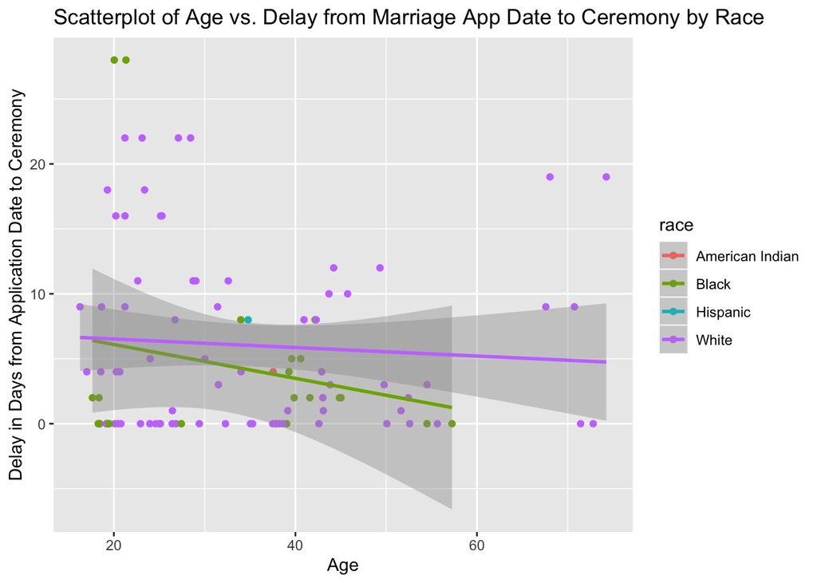

```r
ggplot(Marriage,aes(x= age, y=delay, color=race))+
  geom_point()+
  geom_smooth(method=lm)+
  xlab('Age')+
  ylab('Delay in Days from Application Date to Ceremony')+
  ggtitle('Scatterplot of Age vs. Delay from Marriage App Date to Ceremony by Race')
```

The scatterplot above aims to see if there is a correlation between age and a delay in marraige. A scatterplot was used to to plot the two quantitative variables. A further analysis was conducted to see to seperate the data points by race by using color= in ggplot. We can see that the majority of individuals in this data set were with and there was little to no corelation between age and delay in marriage for this group. The next majority race represented was black, here there was a negative linear relationship between age and delay in marriage. The other races had not enough data points (1 each) to generate a regression line.

Question 3

```r
library(macleish)
head(whately_2015)
```

```
## # A tibble: 6 x 8
##   when                temperature wind_speed wind_dir rel_humidity pressure
##   <dttm>                    <dbl>      <dbl>    <dbl>        <dbl>    <int>
## 1 2015-01-01 00:00:00       -9.32       1.40     225.         54.6      985
## 2 2015-01-01 00:10:00       -9.46       1.51     248.         55.4      985
## 3 2015-01-01 00:20:00       -9.44       1.62     258.         56.2      985
## 4 2015-01-01 00:30:00       -9.3        1.14     244.         56.4      985
## 5 2015-01-01 00:40:00       -9.32       1.22     238.         56.9      984
## 6 2015-01-01 00:50:00       -9.34       1.09     242.         57.2      984
## # … with 2 more variables: solar_radiation <dbl>, rainfall <int>
```

```r
library(tidyverse)
```

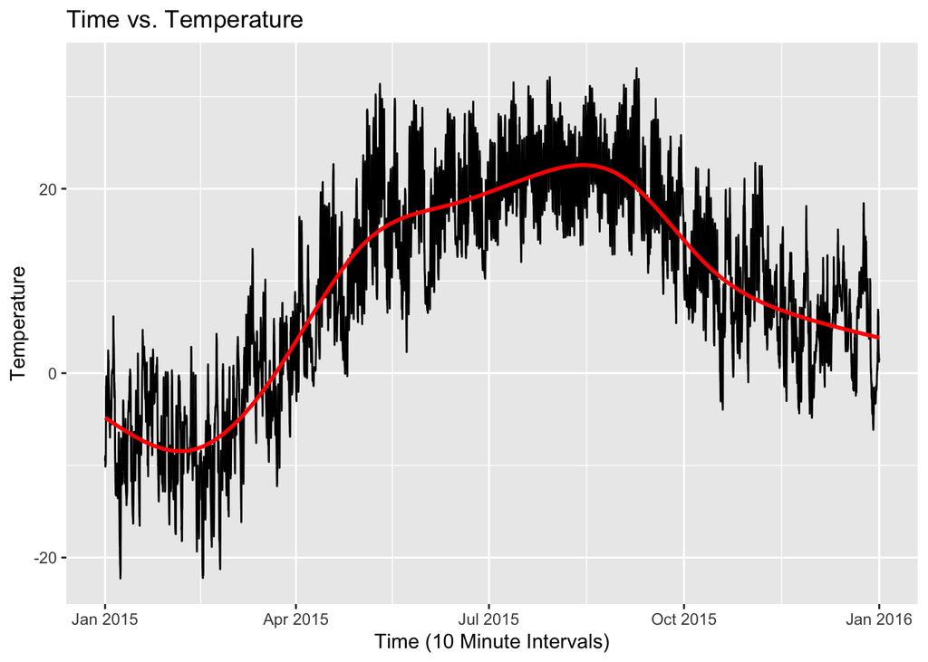

```r
ggplot (whately_2015,aes(x= when, y=temperature))+
  geom_line()+
  geom_smooth(color="red")+
  xlab('Time (10 Minute Intervals)')+
  ylab('Temperature')+
  ggtitle('Time vs. Temperature')
```

Question 4

```r
library(maps)
head(whately_2015)
```

```
## # A tibble: 6 x 8
##   when                temperature wind_speed wind_dir rel_humidity pressure
##   <dttm>                    <dbl>      <dbl>    <dbl>        <dbl>    <int>
## 1 2015-01-01 00:00:00       -9.32       1.40     225.         54.6      985
## 2 2015-01-01 00:10:00       -9.46       1.51     248.         55.4      985
## 3 2015-01-01 00:20:00       -9.44       1.62     258.         56.2      985
## 4 2015-01-01 00:30:00       -9.3        1.14     244.         56.4      985
## 5 2015-01-01 00:40:00       -9.32       1.22     238.         56.9      984
## 6 2015-01-01 00:50:00       -9.34       1.09     242.         57.2      984
## # … with 2 more variables: solar_radiation <dbl>, rainfall <int>
```

```r
library(nasaweather)
```

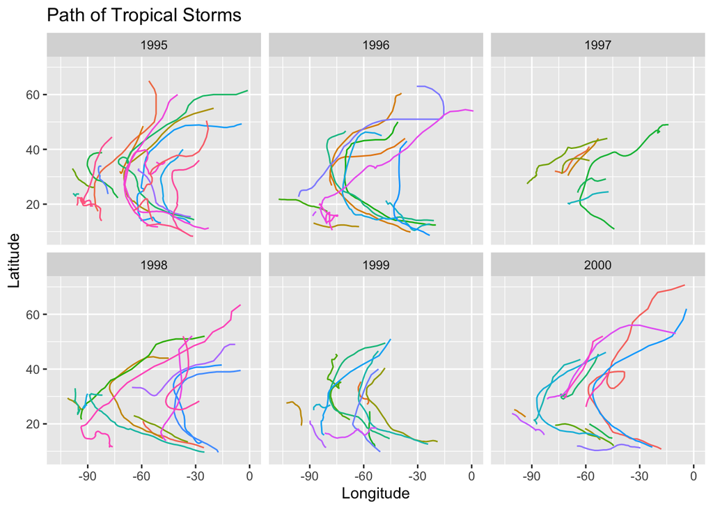

```r
ggplot(storms, aes(y=lat,x=long,color=name))+
  geom_path()+
  facet_wrap(~year)+
  theme(legend.position = "none")+
  xlab('Longitude')+
  ylab('Latitude')+
  ggtitle('Path of Tropical Storms')
```

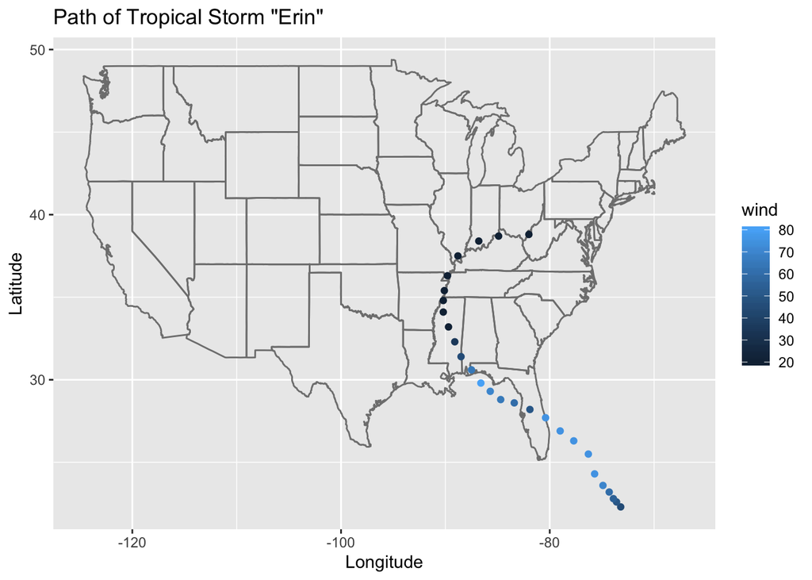

```r
erin<- subset(storms, name== "Erin")
ggplot(erin, aes(x=long, y=lat, color=wind))+
  borders("state")+
  geom_point()+
  xlab('Longitude')+
  ylab('Latitude')+
  ggtitle('Path of Tropical Storm "Erin"')
```